# solution

## Setup

```python
import json, importlib
from pathlib import Path

import warnings
warnings.filterwarnings("ignore", category=Warning, module="tqdm")

import torch
import matplotlib.pyplot as plt
import numpy as np
import math
from nnsight import NNsight
from huggingface_hub import hf_hub_download

device = "cuda" if torch.cuda.is_available() else "cpu"
# print(f"Using device: {device}")

REPO_ID = "andyrdt/05_2026_puzzle_1"
model_py_path = hf_hub_download(REPO_ID, "model.py")
spec = importlib.util.spec_from_file_location("model", model_py_path)
model_module = importlib.util.module_from_spec(spec)
spec.loader.exec_module(model_module)
AttentionOnlyTransformer = model_module.AttentionOnlyTransformer

config_path  = hf_hub_download(REPO_ID, "config.json")
weights_path = hf_hub_download(REPO_ID, "model.pt")

config = json.loads(Path(config_path).read_text())
raw_model = AttentionOnlyTransformer.from_config(config["model"])
raw_model.load_state_dict(torch.load(weights_path, map_location=device, weights_only=True))
raw_model.eval().to(device)
model = NNsight(raw_model)

print(f"Model config: {config['model']}")
print(f"Parameters: {sum(p.numel() for p in model.parameters()):,}")
```

```
Model config: {'vocab_size': 22, 'd_model': 32, 'n_heads': 4, 'n_layers': 2, 'max_seq_len': 12, 'pos_embed_type': 'none'}
Parameters: 9,600
```

## Vocabulary

| Token id range | Role | Render |
| --- | --- | --- |
| `0` – `9` | Input symbols | `a` – `j` |
| `10` | `BOS` | `BOS` |
| `11` | `ANS` | `ANS` |
| `12` – `21` | Count outputs | `#1` – `#10` |

Input sequence: `[BOS, t1, t2, ..., t10, ANS]` (length 12). The model predicts a count token `#k` at the position following `ANS`. Input symbols and count tokens have disjoint id ranges.

```python
NUM_SYMBOLS = config["vocab"]["num_symbols"]   # 10
SEQ_LEN     = config["vocab"]["seq_len"]       # 10
BOS         = NUM_SYMBOLS                       # 10
ANS         = NUM_SYMBOLS + 1                   # 11
COUNT_BASE  = NUM_SYMBOLS + 2                   # 12  (count k -> COUNT_BASE + k - 1)
VOCAB_SIZE  = NUM_SYMBOLS + 2 + SEQ_LEN         # 22

def symbol_to_token(s):
    if isinstance(s, str):
        return ord(s) - ord("a")
    return int(s)

def count_token(k):
    return COUNT_BASE + (k - 1)

def token_label(tok):
    if 0 <= tok < NUM_SYMBOLS:
        return chr(ord("a") + tok)
    if tok == BOS: return "BOS"
    if tok == ANS: return "ANS"
    if COUNT_BASE <= tok < COUNT_BASE + SEQ_LEN:
        return f"#{tok - COUNT_BASE + 1}"
    return f"?{tok}"

def encode(symbols):
    assert len(symbols) == SEQ_LEN, f"Need {SEQ_LEN} symbols, got {len(symbols)}"
    return [BOS] + [symbol_to_token(s) for s in symbols] + [ANS]

def decode_count_token(tok):
    return tok - COUNT_BASE + 1

syms = ['a', 'b', 'a', 'c', 'a', 'b', 'd', 'a', 'c', 'e']
tokens = encode(syms)
print("input symbols   :", syms)
print("input token ids :", tokens)
print("input labels    :", [token_label(t) for t in tokens])
print("true unique cnt :", len(set(syms)))
```

```
input symbols   : ['a', 'b', 'a', 'c', 'a', 'b', 'd', 'a', 'c', 'e']
input token ids : [10, 0, 1, 0, 2, 0, 1, 3, 0, 2, 4, 11]
input labels    : ['BOS', 'a', 'b', 'a', 'c', 'a', 'b', 'd', 'a', 'c', 'e', 'ANS']
true unique cnt : 5
```

```python
def plot_attention(attn_patterns, token_labels, title="Attention"):
    if not isinstance(attn_patterns, list):
        attn_patterns = [attn_patterns]
    n_layers = len(attn_patterns)
    n_heads = attn_patterns[0].shape[0]
    fig, axes = plt.subplots(n_layers, n_heads, figsize=(3.4 * n_heads, 3.0 * n_layers),
                             squeeze=False)
    for L, attn in enumerate(attn_patterns):
        attn = attn.detach().cpu().numpy()
        for h in range(n_heads):
            ax = axes[L][h]
            ax.imshow(attn[h], cmap="Blues", vmin=0, vmax=1)
            ax.set_xticks(range(len(token_labels)))
            ax.set_xticklabels(token_labels, rotation=45, ha="right",
                               rotation_mode="anchor", fontsize=8)
            ax.set_yticks(range(len(token_labels)))
            ax.set_yticklabels(token_labels, fontsize=8)
            ax.set_title(f"Layer {L}, Head {h}", fontsize=10)
    fig.suptitle(title)
    fig.tight_layout()
    plt.show()
```

## Running the model with `nnsight`

[`nnsight`](https://nnsight.net/) lets you capture activations and run interventions inside a `with model.trace(x): ...` block:

```
with model.trace(x):
    out = model.output.save()
logits, attn_patterns = out
```

Intermediate activations work the same way (e.g. `model.layers[0].output.save()`); interventions are in-place mutations of activation tensors inside the block.

## Example outputs

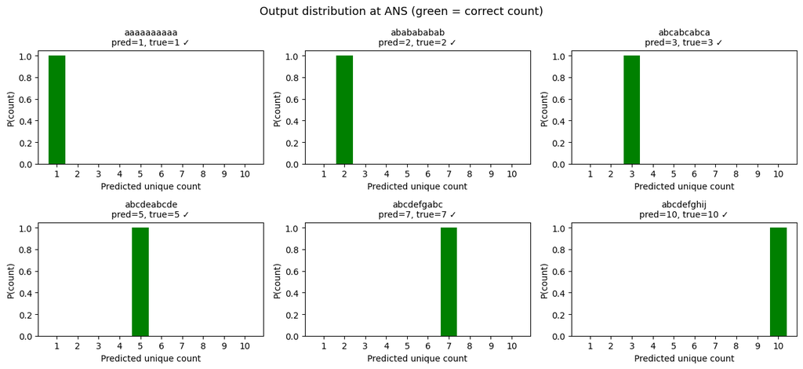

```python
examples = [
    ['a','a','a','a','a','a','a','a','a','a'],   # 1 unique
    ['a','b','a','b','a','b','a','b','a','b'],   # 2 unique
    ['a','b','c','a','b','c','a','b','c','a'],   # 3 unique
    ['a','b','c','d','e','a','b','c','d','e'],   # 5 unique
    ['a','b','c','d','e','f','g','a','b','c'],   # 7 unique
    ['a','b','c','d','e','f','g','h','i','j'],   # 10 unique
]

fig, axes = plt.subplots(2, 3, figsize=(13, 6))
for ax, syms in zip(axes.flat, examples):
    x = torch.tensor([encode(syms)], device=device)

    with model.trace(x):
        out = model.output.save()
    logits, _ = out

    count_logits = logits[0, -1, COUNT_BASE:COUNT_BASE + SEQ_LEN]
    probs = torch.softmax(count_logits, dim=-1).detach().cpu()
    pred_count = int(probs.argmax().item()) + 1
    true_count = len(set(syms))

    colors = ["green" if k + 1 == true_count else "lightgray" for k in range(SEQ_LEN)]
    ax.bar(range(1, SEQ_LEN + 1), probs.numpy(), color=colors)
    ax.set_xticks(range(1, SEQ_LEN + 1))
    ax.set_xlabel("Predicted unique count")
    ax.set_ylabel("P(count)")
    ax.set_ylim(0, 1.05)
    status = "✓" if pred_count == true_count else "✗"
    ax.set_title(f"{''.join(syms)}\npred={pred_count}, true={true_count} {status}", fontsize=10)

plt.suptitle("Output distribution at ANS (green = correct count)", fontsize=13)
plt.tight_layout()
plt.show()
```

## Attention patterns

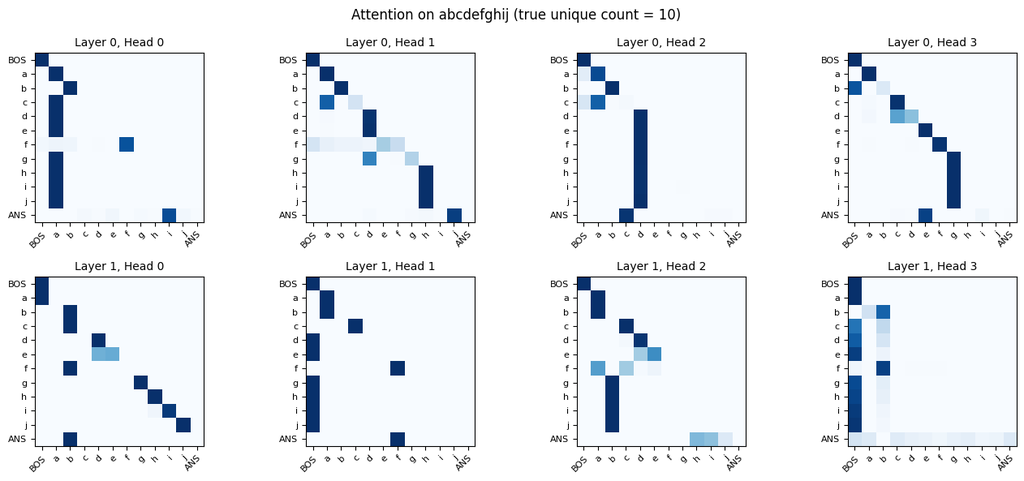

```python
syms = ['a','b','c','d','e','f','g','h','i','j']  # 10 unique
tokens = encode(syms)
x = torch.tensor([tokens], device=device)

with model.trace(x):
    out = model.output.save()
_, attn_patterns = out
labels = [token_label(t) for t in tokens]

plot_attention(
    [attn_patterns[0][0], attn_patterns[1][0]],
    labels,
    title=f"Attention on {''.join(syms)} (true unique count = {len(set(syms))})",
)
```

## Solution

Below we show the bar charts for the QK scores for all attention heads in layer 0.

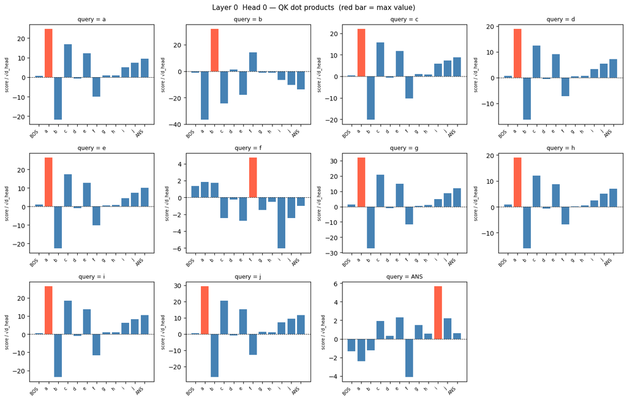

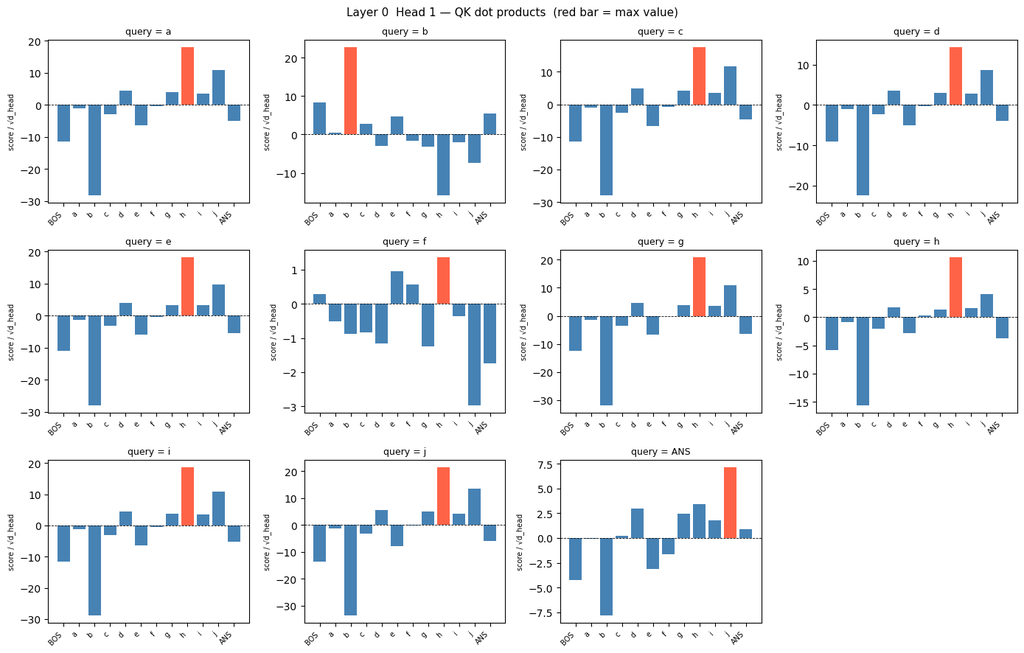

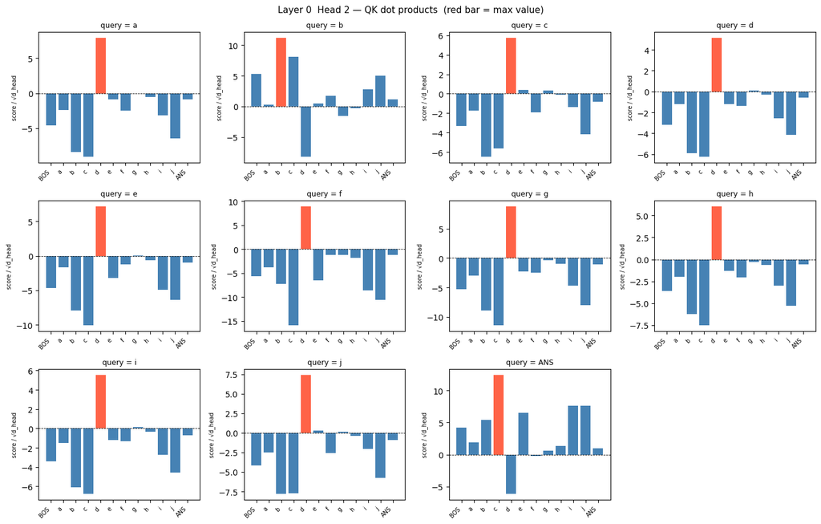

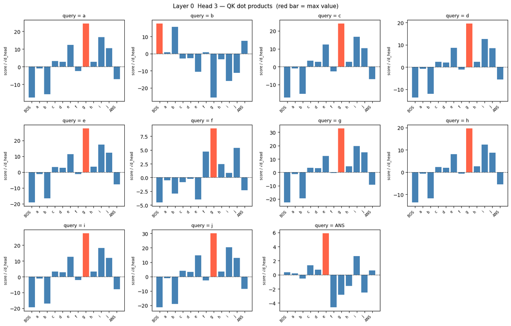

```python
"""
For layer 0, heads 0-3: for each query token (a-j, ANS), plot a bar chart of
the normalised QK dot products with each key token (a-j, BOS).

score(q, k) = (W_Q @ embed(q)) · (W_K @ embed(k)) / sqrt(d_head)
"""

# ── dims ──────────────────────────────────────────────────────────────────────
d_model = raw_model.d_model
n_heads = raw_model.n_heads
d_head  = d_model // n_heads
scale   = math.sqrt(d_head)

query_tokens = list(range(NUM_SYMBOLS)) + [ANS]   # a-j + ANS  (11)
key_tokens   = [BOS] + list(range(NUM_SYMBOLS)) + [ANS]   # a-j + BOS + ANS  (12)
q_labels     = [token_label(t) for t in query_tokens]
k_labels     = [token_label(t) for t in key_tokens]

E = raw_model.tok_embed.weight.detach().cpu()  # (22, d_model)
E_q = E[query_tokens]  # (11, d_model)
E_k = E[key_tokens]    # (11, d_model)

n_q = len(query_tokens)  # 11
n_k = len(key_tokens)    # 11

# ── plot: one figure per head ─────────────────────────────────────────────────
for h in range(n_heads):
    W_Q = raw_model.layers[0].heads[h].W_Q.weight.detach().cpu()  # (d_head, d_model)
    W_K = raw_model.layers[0].heads[h].W_K.weight.detach().cpu()

    Q = E_q @ W_Q.T  # (n_q, d_head)
    K = E_k @ W_K.T  # (n_k, d_head)

    scores = (Q @ K.T) / scale  # (n_q, n_k)

    ncols = 4
    nrows = math.ceil(n_q / ncols)
    fig, axes = plt.subplots(nrows, ncols, figsize=(ncols * 3.5, nrows * 3),
                             squeeze=False)

    x = np.arange(n_k)
    for qi, (q_tok, q_lbl) in enumerate(zip(query_tokens, q_labels)):
        row, col = divmod(qi, ncols)
        ax = axes[row][col]
        vals = scores[qi].numpy()
        bar_colors = ["steelblue" if ki != vals.argmax() else "tomato"
                      for ki, k_tok in enumerate(key_tokens)]
        ax.bar(x, vals, color=bar_colors)
        ax.axhline(0, color="black", linewidth=0.6, linestyle="--")
        ax.set_title(f"query = {q_lbl}", fontsize=9)
        ax.set_xticks(x)
        ax.set_xticklabels(k_labels, fontsize=7, rotation=45, ha="right")
        ax.set_ylabel("score / √d_head", fontsize=7)

    # hide unused subplots
    for qi in range(n_q, nrows * ncols):
        row, col = divmod(qi, ncols)
        axes[row][col].set_visible(False)

    fig.suptitle(f"Layer 0  Head {h} — QK dot products  (red bar = max value)",
                 fontsize=11)
    fig.tight_layout()
    plt.show()
```

We observe the following:

**Head 1**

- When `[ANS]` is the query, the highest value is obtained by the token `j`
- For the remaining tokens, except for token `b`, the highest value is obtained when the key token is `h`
- When the query is `b`, the highest value for the key token is obtained by `b` itself

**Head 2**

- When `[ANS]` is the query, the highest value is obtained by the token `c`
- For the remaining tokens, except for token `b`, the highest value is obtained when the key token is `d`
- When the query is `b`, the highest value for the key token is obtained by `b` itself

**Head 3**

- When `[ANS]` is the query, the highest value is obtained by the token `e`
- For the remaining tokens, except for token `b`, the highest value is obtained when the key token is `g`
- When the query is `b`, the highest value for the key token is obtained by `[BOS]`

From the above observations, we can claim that:

Roughly speaking, after layer 0, `[ANS]` has information that `i`, `j`, `c` and `e` are present. Similarly, after layer 0, except for `b`, the other tokens have information that `a`, `h`, `d` and `g` occur previously before them. The special token `b` does not accrue any information about other tokens except itself and `[BOS]`.

Here below we plot the 2 dimensional truncated SVD of the unembedding matrix taking only the numerical tokens

```python
"""
Interactive unnormalized TruncatedSVD plot using plotly.
Zoom/pan in browser to explore clustering near the origin.
"""

import json
import importlib
from pathlib import Path

import torch
import numpy as np
import plotly.graph_objects as go
from sklearn.decomposition import TruncatedSVD
from huggingface_hub import hf_hub_download

# ── load model ────────────────────────────────────────────────────────────────
REPO_ID = "andyrdt/05_2026_puzzle_1"
model_py_path = hf_hub_download(REPO_ID, "model.py")
spec = importlib.util.spec_from_file_location("model", model_py_path)
model_module = importlib.util.module_from_spec(spec)
spec.loader.exec_module(model_module)
AttentionOnlyTransformer = model_module.AttentionOnlyTransformer

config = json.loads(Path(hf_hub_download(REPO_ID, "config.json")).read_text())
raw_model = AttentionOnlyTransformer.from_config(config["model"])
raw_model.load_state_dict(
    torch.load(hf_hub_download(REPO_ID, "model.pt"), map_location="cpu", weights_only=True)
)
raw_model.eval()

# ── vocab ─────────────────────────────────────────────────────────────────────
NUM_SYMBOLS = config["vocab"]["num_symbols"]
SEQ_LEN     = config["vocab"]["seq_len"]
BOS         = NUM_SYMBOLS
ANS         = NUM_SYMBOLS + 1
COUNT_BASE  = NUM_SYMBOLS + 2

def sym(ch): return ord(ch) - ord("a")

def token_label(tok):
    if 0 <= tok < NUM_SYMBOLS: return chr(ord("a") + tok)
    if tok == BOS:             return "BOS"
    if tok == ANS:             return "ANS"
    if COUNT_BASE <= tok < COUNT_BASE + SEQ_LEN:
        return f"#{tok - COUNT_BASE + 1}"
    return f"?{tok}"

count_labels  = [token_label(COUNT_BASE + i) for i in range(SEQ_LEN)]
symbol_labels = [token_label(i) for i in range(NUM_SYMBOLS)]

# ── weights ───────────────────────────────────────────────────────────────────
W_E  = raw_model.tok_embed.weight.detach().cpu().numpy()
W_U  = raw_model.unembed.weight.detach().cpu().numpy()
W_O  = raw_model.layers[0].W_O.weight.detach().cpu().numpy()
W_O2 = raw_model.layers[1].W_O.weight.detach().cpu().numpy()
d_model = W_E.shape[1]

def ov_vector(head_toks):
    chunks = []
    for h, tok in enumerate(head_toks):
        W_V = raw_model.layers[0].heads[h].W_V.weight.detach().cpu().numpy()
        chunks.append(W_V @ W_E[tok] if tok is not None else np.zeros(d_model // 4))
    return (W_O @ np.concatenate(chunks))[None, :]

def head_tokens_for(t):
    h0 = t if t == sym("b") else (sym("f") if t == sym("f") else sym("a"))
    h1 = t if t == sym("b") else sym("h")
    h2 = t if t == sym("b") else sym("d")
    h3 = BOS if t == sym("b") else sym("g")
    return [h0, h1, h2, h3]

# ── compute vectors ───────────────────────────────────────────────────────────
W_U_counts = W_U[COUNT_BASE : COUNT_BASE + SEQ_LEN]
W_E_ans    = W_E[ANS : ANS + 1]

ov_vec = ov_vector([sym("i"), sym("j"), sym("c"), sym("e")])
ans_plus_ov = W_E_ans + ov_vec

ov_ijc0 = ov_vector([sym("i"), sym("j"), sym("c"), None])
ov_ij00 = ov_vector([sym("i"), sym("j"), None,     None])
ov_i000 = ov_vector([sym("i"), None,     None,     None])

tok_plus_ov_vecs = np.stack([
    W_E[t] + ov_vector(head_tokens_for(t))[0] for t in range(NUM_SYMBOLS)
])

act_b = tok_plus_ov_vecs[sym("b")]
act_f = tok_plus_ov_vecs[sym("f")]
act_e = tok_plus_ov_vecs[sym("e")]
act_0 = np.zeros(d_model)

chunks2 = []
for h, act in enumerate([act_b, act_f, act_e, act_0]):
    W_V2 = raw_model.layers[1].heads[h].W_V.weight.detach().cpu().numpy()
    chunks2.append(W_V2 @ act)
ov_layer2_vec = (W_O2 @ np.concatenate(chunks2))[None, :]

chunks_bf00 = []
for h, act in enumerate([act_b, act_f, act_0, act_0]):
    W_V2 = raw_model.layers[1].heads[h].W_V.weight.detach().cpu().numpy()
    chunks_bf00.append(W_V2 @ act)
ov_layer2_bf00 = (W_O2 @ np.concatenate(chunks_bf00))[None, :]

W_V0 = raw_model.layers[0].heads[0].W_V.weight.detach().cpu().numpy()
ov_e_h0 = (W_O @ np.concatenate([W_V0 @ W_E[sym("e")], np.zeros(3 * (d_model // 4))]))[None, :]

ov_eeee = ov_vector([sym("e"), sym("e"), sym("e"), sym("e")])

# ── TruncatedSVD on raw (unnormalized) W_U_counts ────────────────────────────
svd = TruncatedSVD(n_components=2, random_state=42)
svd.fit(W_U_counts)

def proj(v):
    return svd.transform(v)

p_counts        = proj(W_U_counts)
p_ans           = proj(W_E_ans)
p_ov            = proj(ov_vec)
p_ans_ov        = proj(ans_plus_ov)
p_ans_ov_ijc0       = proj(W_E_ans + ov_ijc0)
p_ans_ov_ij00       = proj(W_E_ans + ov_ij00)
p_ans_ov_i000       = proj(W_E_ans + ov_i000)
p_ans_ov_l1_l2_bf00 = proj(W_E_ans + ov_vec + ov_layer2_bf00)
p_tok_ov      = proj(tok_plus_ov_vecs)
p_ov_l2       = proj(ov_layer2_vec)
p_ans_ov_l2   = proj(W_E_ans + ov_vec + ov_layer2_vec)
p_ov_l2_bf00  = proj(ov_layer2_bf00)
p_ov_e_h0     = proj(ov_e_h0)
p_ans_ov_e_h0 = proj(W_E_ans + ov_e_h0)
p_ans_ov_eeee = proj(W_E_ans + ov_eeee)

# ── build plotly figure ───────────────────────────────────────────────────────
fig = go.Figure()

def add_scatter(coords, labels, name, color, symbol="circle", size=10):
    fig.add_trace(go.Scatter(
        x=coords[:, 0], y=coords[:, 1],
        mode="markers+text",
        name=name,
        text=labels,
        textposition="top right",
        textfont=dict(size=10, color=color),
        marker=dict(color=color, size=size, symbol=symbol),
    ))

add_scatter(p_counts,      count_labels,   "W_U count (#1–#10)", "seagreen",     size=10)
ans_norm_ratio = np.linalg.norm(p_ans) / np.linalg.norm(W_E_ans)
add_scatter(p_ans, [f"ANS  ‖proj(ANS)‖/‖ANS‖={ans_norm_ratio:.3f}"], "W_E ANS", "tomato", size=10)
# add_scatter(p_ans,         ["ANS"],        "W_E ANS",            "tomato",       size=10)

var = svd.explained_variance_ratio_
fig.update_layout(
    title="Truncated SVD (rank 2) of unembedding matrix (numerical tokens only). ANS token projected.",
    xaxis_title=f"SV1  ({var[0]*100:.1f}% var)",
    yaxis_title=f"SV2  ({var[1]*100:.1f}% var)",
    legend=dict(font=dict(size=10)),
    width=1000, height=750,
    hovermode="closest",
)
fig.add_hline(y=0, line=dict(color="grey", width=0.5, dash="dash"))
fig.add_vline(x=0, line=dict(color="grey", width=0.5, dash="dash"))

fig.show()
```

[interactive chart not shown]

Note that the numerical tokens are aranged in their natural order around the origin. We also project the `[ANS]` token onto this subspace and note that it points between the unembedding vector of tokens `5` and `6`.

In the figure below, we plot the projections of `OV<i,j,c,e>` and `ANS + OV<i,j,c,e>`.

- Here $OV$ denotes the applicaiton of $W_{O}$ to the value at `ANS` position in layer 0.
- Note that from our observations above the `ANS` token in head 0 attends to `i`, in head 1 attends to `j`, in head 2 attends to `c`, and in head 3 attends to `e`.
- `<i, j, c, e>` denotes the concatenation of the value vectors of the tokens `i`, `j`, `c`, and `e`.
- Also, note that we are implicitly making the assumption that `i, j, c, e` are present in the input sequence.

```python
fig = go.Figure()
add_scatter(p_counts,      count_labels,   "W_U count (#1–#10)", "seagreen",     size=10)
ans_norm_ratio = np.linalg.norm(p_ans) / np.linalg.norm(W_E_ans)
add_scatter(p_ans, [f"ANS <br>‖proj(ANS)‖/‖ANS‖={ans_norm_ratio:.3f}"], "W_E ANS", "tomato", size=10)
add_scatter(p_ov,          ["OV<i,j,c,e>"],        "OV<i,j,c,e>",        "steelblue",    symbol="star",    size=14)
ans_layer0_norm_ratio = np.linalg.norm(p_ans_ov) / np.linalg.norm(ans_plus_ov)
add_scatter(p_ans_ov,    [f"ANS+OV<i,j,c,e>  <br>‖proj(ANS+OV<i,j,c,e>)‖/‖ANS+OV<i,j,c,e>‖={ans_layer0_norm_ratio:.3f}"],    "ANS+OV<i,j,c,e>",   "mediumpurple", symbol="diamond", size=12)

var = svd.explained_variance_ratio_
fig.update_layout(
    title="TruncatedSVD of unembedding matrix (numerical tokens only)",
    xaxis_title=f"SV1  ({var[0]*100:.1f}% var)",
    yaxis_title=f"SV2  ({var[1]*100:.1f}% var)",
    legend=dict(font=dict(size=10)),
    width=1000, height=750,
    hovermode="closest",
)
fig.add_hline(y=0, line=dict(color="grey", width=0.5, dash="dash"))
fig.add_vline(x=0, line=dict(color="grey", width=0.5, dash="dash"))

fig.show()
```

[interactive chart not shown]

Roughly, the addition of `OV<i,j,c,e>` pushes the `ANS` logit towards `4` (this is expected).

## Layer 1 analysis

- Note that layer 1 analysis is more complicated as the attention heads operate now on the activations from layer (previously it was token embeddings). So we need to keep track of what information each token holds after layer 0 apart from information about itself.
- From our observations, we know that except for `b` all other tokens attended to `a`, `d`, `h`, and `g`.
- Notation: $\tilde{token}$ will denote the activation of `token` after layer 0.

Firstly, we claim that heads 0 and 1 in layer 1, always attend to $\tilde{b}$ and $\tilde{f}$ respectively. In order to justify this claim, we will use a heuristic argument where we randomly sample sequences containing and make bar chart of the average attention weights for the `ANS` position at heads 0 and 1 in layer 1 across the samples.

- Note that head 0 attends to `b` if present, and `BOS` if `b` is not present.
- We will show that head 0 is inconsequential for the output if `b` is not present, and head 1 is inconsequential for the output if `f` is not present.

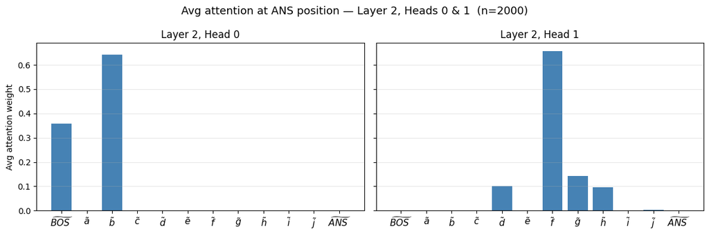

```python
"""
Bar chart of average attention weights at the ANS position,
layer 1 heads 0 and 1, averaged over N randomly sampled input sequences.

Sequence format: [BOS, s_1, ..., s_SEQ_LEN, ANS]
X-axis: token type (a-j, BOS, ANS).
Within each sequence, attention to all positions with the same token is summed.
That sum is then averaged across sequences, so bars sum to ~1.
"""

import json
import importlib
from pathlib import Path

import torch
import numpy as np
import matplotlib.pyplot as plt
from huggingface_hub import hf_hub_download

# ── load model ────────────────────────────────────────────────────────────────
REPO_ID = "andyrdt/05_2026_puzzle_1"
model_py_path = hf_hub_download(REPO_ID, "model.py")
spec = importlib.util.spec_from_file_location("model", model_py_path)
model_module = importlib.util.module_from_spec(spec)
spec.loader.exec_module(model_module)
AttentionOnlyTransformer = model_module.AttentionOnlyTransformer

config = json.loads(Path(hf_hub_download(REPO_ID, "config.json")).read_text())
raw_model = AttentionOnlyTransformer.from_config(config["model"])
raw_model.load_state_dict(
    torch.load(hf_hub_download(REPO_ID, "model.pt"), map_location="cpu", weights_only=True)
)
raw_model.eval()

# ── vocab ─────────────────────────────────────────────────────────────────────
NUM_SYMBOLS = config["vocab"]["num_symbols"]
SEQ_LEN     = config["vocab"]["seq_len"]
BOS         = NUM_SYMBOLS
ANS         = NUM_SYMBOLS + 1

def token_label(tok):
    if 0 <= tok < NUM_SYMBOLS: return chr(ord("a") + tok)
    if tok == BOS:             return "BOS"
    if tok == ANS:             return "ANS"
    return f"?{tok}"

# ── config ────────────────────────────────────────────────────────────────────
SEQ_TOTAL  = SEQ_LEN + 2
ANS_POS    = SEQ_LEN + 1
N_SAMPLES  = 2000
BATCH_SIZE = 256

TOKEN_TYPES  = [BOS] + list(range(NUM_SYMBOLS)) + [ANS]

def tilde_label(tok):
    if 0 <= tok < NUM_SYMBOLS: return r"$\tilde{" + chr(ord("a") + tok) + r"}$"
    if tok == BOS:             return r"$\widetilde{BOS}$"
    if tok == ANS:             return r"$\widetilde{ANS}$"
    return f"?{tok}"

TOKEN_LABELS = [tilde_label(t) for t in TOKEN_TYPES]

# ── sample and accumulate ─────────────────────────────────────────────────────
# For each sequence: sum attention over all positions sharing a token type.
# Then average those sums across N_SAMPLES sequences.
attn_sum = np.zeros((2, len(TOKEN_TYPES)))  # (head, token_type)

with torch.no_grad():
    for start in range(0, N_SAMPLES, BATCH_SIZE):
        n = min(BATCH_SIZE, N_SAMPLES - start)

        seqs = torch.zeros(n, SEQ_TOTAL, dtype=torch.long)
        seqs[:, 0] = BOS
        seqs[:, 1:SEQ_LEN + 1] = torch.randint(0, NUM_SYMBOLS, (n, SEQ_LEN))
        seqs[:, ANS_POS] = ANS

        _, all_attns = raw_model(seqs)
        # all_attns[1]: (batch, n_heads, SEQ_TOTAL, SEQ_TOTAL)
        attn = all_attns[1][:, :2, ANS_POS, :].numpy()  # (n, 2, SEQ_TOTAL)

        seqs_np = seqs.numpy()  # (n, SEQ_TOTAL)
        for tok_idx, tok in enumerate(TOKEN_TYPES):
            mask = (seqs_np == tok)                               # (n, SEQ_TOTAL)
            # sum over positions per sequence, then sum over batch
            attn_sum[:, tok_idx] += (attn * mask[:, None, :]).sum(axis=(0, 2))

attn_avg = attn_sum / N_SAMPLES  # (2, num_token_types)

# ── plot ──────────────────────────────────────────────────────────────────────
fig, axes = plt.subplots(1, 2, figsize=(12, 4), sharey=True)

for h, ax in enumerate(axes):
    ax.bar(range(len(TOKEN_LABELS)), attn_avg[h], color="steelblue")
    ax.set_xticks(range(len(TOKEN_LABELS)))
    ax.set_xticklabels(TOKEN_LABELS, fontsize=11)
    ax.set_title(f"Layer 2, Head {h}", fontsize=12)
    ax.set_ylabel("Avg attention weight" if h == 0 else "")
    ax.grid(True, axis="y", alpha=0.3)

fig.suptitle(f"Avg attention at ANS position — Layer 2, Heads 0 & 1  (n={N_SAMPLES})", fontsize=13)
fig.tight_layout()
plt.show()
```

In the figure below we show the average attnetion weights at `ANS` position in heads 2 and 3 over samples.

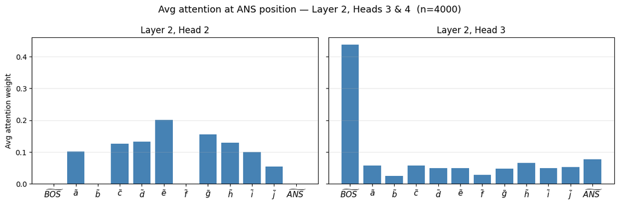

```python
"""
Bar chart of average attention weights at the ANS position,
layer 2 heads 3 and 4 (0-indexed: 2 and 3), averaged over N randomly sampled input sequences.

Sequence format: [BOS, s_1, ..., s_SEQ_LEN, ANS]
X-axis: token type (a-j, BOS, ANS).
Within each sequence, attention to all positions with the same token is summed.
That sum is then averaged across sequences, so bars sum to ~1.
"""

import json
import importlib
from pathlib import Path

import torch
import numpy as np
import matplotlib.pyplot as plt
from huggingface_hub import hf_hub_download

# ── load model ────────────────────────────────────────────────────────────────
REPO_ID = "andyrdt/05_2026_puzzle_1"
model_py_path = hf_hub_download(REPO_ID, "model.py")
spec = importlib.util.spec_from_file_location("model", model_py_path)
model_module = importlib.util.module_from_spec(spec)
spec.loader.exec_module(model_module)
AttentionOnlyTransformer = model_module.AttentionOnlyTransformer

config = json.loads(Path(hf_hub_download(REPO_ID, "config.json")).read_text())
raw_model = AttentionOnlyTransformer.from_config(config["model"])
raw_model.load_state_dict(
    torch.load(hf_hub_download(REPO_ID, "model.pt"), map_location="cpu", weights_only=True)
)
raw_model.eval()

# ── vocab ─────────────────────────────────────────────────────────────────────
NUM_SYMBOLS = config["vocab"]["num_symbols"]
SEQ_LEN     = config["vocab"]["seq_len"]
BOS         = NUM_SYMBOLS
ANS         = NUM_SYMBOLS + 1

# ── config ────────────────────────────────────────────────────────────────────
SEQ_TOTAL  = SEQ_LEN + 2
ANS_POS    = SEQ_LEN + 1
N_SAMPLES  = 4000
BATCH_SIZE = 256

HEAD_INDICES = [2, 3]   # 0-indexed; heads 3 and 4 in 1-indexed notation
HEAD_LABELS  = ["Head 2", "Head 3"]

TOKEN_TYPES = [BOS] + list(range(NUM_SYMBOLS)) + [ANS]

def tilde_label(tok):
    if 0 <= tok < NUM_SYMBOLS: return r"$\tilde{" + chr(ord("a") + tok) + r"}$"
    if tok == BOS:             return r"$\widetilde{BOS}$"
    if tok == ANS:             return r"$\widetilde{ANS}$"
    return f"?{tok}"

TOKEN_LABELS = [tilde_label(t) for t in TOKEN_TYPES]

# ── sample and accumulate ─────────────────────────────────────────────────────
attn_sum = np.zeros((2, len(TOKEN_TYPES)))  # (head slot, token_type)

with torch.no_grad():
    for start in range(0, N_SAMPLES, BATCH_SIZE):
        n = min(BATCH_SIZE, N_SAMPLES - start)

        seqs = torch.zeros(n, SEQ_TOTAL, dtype=torch.long)
        seqs[:, 0] = BOS
        seqs[:, 1:SEQ_LEN + 1] = torch.randint(0, NUM_SYMBOLS, (n, SEQ_LEN))
        seqs[:, ANS_POS] = ANS

        _, all_attns = raw_model(seqs)
        # all_attns[1]: (batch, n_heads, SEQ_TOTAL, SEQ_TOTAL)
        attn = all_attns[1][:, HEAD_INDICES, ANS_POS, :].numpy()  # (n, 2, SEQ_TOTAL)

        seqs_np = seqs.numpy()
        for tok_idx, tok in enumerate(TOKEN_TYPES):
            mask = (seqs_np == tok)                               # (n, SEQ_TOTAL)
            attn_sum[:, tok_idx] += (attn * mask[:, None, :]).sum(axis=(0, 2))

attn_avg = attn_sum / N_SAMPLES  # (2, num_token_types)

# ── plot ──────────────────────────────────────────────────────────────────────
fig, axes = plt.subplots(1, 2, figsize=(12, 4), sharey=True)

for i, (ax, lbl) in enumerate(zip(axes, HEAD_LABELS)):
    ax.bar(range(len(TOKEN_LABELS)), attn_avg[i], color="steelblue")
    ax.set_xticks(range(len(TOKEN_LABELS)))
    ax.set_xticklabels(TOKEN_LABELS, fontsize=11)
    ax.set_title(f"Layer 2, {lbl}", fontsize=12)
    ax.set_ylabel("Avg attention weight" if i == 0 else "")
    ax.grid(True, axis="y", alpha=0.3)

fig.suptitle(f"Avg attention at ANS position — Layer 2, Heads 3 & 4  (n={N_SAMPLES})", fontsize=13)
fig.tight_layout()
plt.show()
```

- We note that in head 3, the $\widetilde{ANS}$ attends to $\widetilde{BOS}$ and almost uniformly to other tokens. We haven't been able to completely explain the causal mechanism of head 3, but here below we show an ablation test where we ablate head 3. In particular, we zero out the components for head 3 in layer 1, and test accuracy on samples grouped by the unique count.

### Head 2 Layer 1

Now we claim that head 2 tracks information on the remaining tokens that haven't been accounted for—namely, tokens `a`, `d`,`h` and `g`.

From the orignal barcharts we know the attention patterns for each token. So we set: $\tilde{b} = b + OV<b,b,b,BOS>$ $\tilde{f} = f + OV<f,h,d,g>$ $\widetilde{ANS} = ANS + OV<i,j,c,e>$ $\widetilde{tok} = tok + OV<a,h,d,g>$ for all other alphabetical tokens

In the plot below, we show the 2d pca plot as before and the projection of

$$\widetilde{ANS} + \tilde{OV}<\tilde{b},\tilde{f},0 ,0> $$

and

$$\widetilde{ANS} + \tilde{OV}<\tilde{b},\tilde{f},\tilde{e},0> $$

```python
plt.rcParams['text.usetex'] = True
fig = go.Figure()
add_scatter(p_counts,      count_labels,   "W_U count (#1–#10)", "seagreen",     size=10)
ans_norm_ratio = np.linalg.norm(p_ans) / np.linalg.norm(W_E_ans)
add_scatter(p_ans, [f"ANS <br>‖proj(ANS)‖/‖ANS‖={ans_norm_ratio:.3f}"], "W_E ANS", "tomato", size=10)
add_scatter(p_ov,          ["OV<i,j,c,e>"],        "OV<i,j,c,e>",        "steelblue",    symbol="star",    size=14)
ans_layer0_norm_ratio = np.linalg.norm(p_ans_ov) / np.linalg.norm(ans_plus_ov)
add_scatter(p_ans_ov,    [f"ANS+OV<i,j,c,e>  <br>‖proj(ANS+OV<i,j,c,e>)‖/‖ANS+OV<i,j,c,e>‖={ans_layer0_norm_ratio:.3f}"],    "ANS+OV<i,j,c,e>",   "mediumpurple", symbol="diamond", size=12)
add_scatter(p_ans_ov_l1_l2_bf00, [r"$ANS+OV<i,j,c,e>+\tilde{OV}<\tilde{b},\tilde{f},0,0>$"], "ANS+OV_L1<i,j,c,e>+OV_L2<[b],[f],0,0>", "darkslategray", symbol="x", size=14)
add_scatter(p_ans_ov_l2,   [r"$ANS+OV<i,j,c,e>+\tilde{OV}<\tilde{b},\tilde{f},\tilde{e},0>$"],    "ANS+OV_L1<i,j,c,e>+OV_L2<[b],[f],[e],0>",   "black",        symbol="x",       size=14)

var = svd.explained_variance_ratio_
fig.update_layout(
    title="TruncatedSVD of unembedding matrix (numerical tokens only)",
    xaxis_title=f"SV1  ({var[0]*100:.1f}% var)",
    yaxis_title=f"SV2  ({var[1]*100:.1f}% var)",
    legend=dict(font=dict(size=10)),
    width=1000, height=750,
    hovermode="closest",
)
fig.add_hline(y=0, line=dict(color="grey", width=0.5, dash="dash"))
fig.add_vline(x=0, line=dict(color="grey", width=0.5, dash="dash"))

fig.show()
```

[interactive chart not shown]

The reader will have to traverse the plot to notice that $ANS+OV<i,j,c,e>+\tilde{OV}<\tilde{b},\tilde{f},0,0>$ has a comparatively high magnitude and points towards the ~ 6,7 direction.

### Head 3 Layer 1

```python
import warnings
warnings.filterwarnings("ignore", category=Warning, module="tqdm")

import copy
import json
import importlib
import importlib.util
from pathlib import Path

import numpy as np
import torch
import torch.nn.functional as F
from torch.utils.data import DataLoader, Dataset, TensorDataset
from huggingface_hub import hf_hub_download

# ── Load model ────────────────────────────────────────────────────────────────
REPO_ID = "andyrdt/05_2026_puzzle_1"

model_py_path = hf_hub_download(REPO_ID, "model.py")
spec = importlib.util.spec_from_file_location("model", model_py_path)
model_module = importlib.util.module_from_spec(spec)
spec.loader.exec_module(model_module)
AttentionOnlyTransformer = model_module.AttentionOnlyTransformer

config = json.loads(Path(hf_hub_download(REPO_ID, "config.json")).read_text())
model = AttentionOnlyTransformer.from_config(config["model"])
model.load_state_dict(
    torch.load(hf_hub_download(REPO_ID, "model.pt"), map_location="cpu", weights_only=True)
)
model.eval()

vocab_cfg = config["vocab"]
NUM_SYMBOLS = vocab_cfg["num_symbols"]   # 10
SEQ_LEN     = vocab_cfg["seq_len"]       # 10
BOS         = NUM_SYMBOLS
ANS         = NUM_SYMBOLS + 1
COUNT_BASE  = NUM_SYMBOLS + 2
VOCAB_SIZE  = config["model"]["vocab_size"]
ANS_POS     = 1 + SEQ_LEN  # position in input that predicts count token

d_model = config["model"]["d_model"]
n_heads = config["model"]["n_heads"]
d_head  = d_model // n_heads


# ── Data generation ───────────────────────────────────────────────────────────
def generate_test_data(num_symbols, seq_len, samples_per_count=500, seed=42):
    rng = np.random.default_rng(seed)
    all_seqs, all_targets = [], []
    for c in range(1, seq_len + 1):
        generated = set()
        attempts = 0
        while len(generated) < samples_per_count and attempts < samples_per_count * 50:
            symbols = rng.choice(num_symbols, size=c, replace=False)
            extras  = rng.choice(symbols, size=seq_len - c, replace=True)
            seq = np.concatenate([symbols, extras])
            rng.shuffle(seq)
            generated.add(tuple(int(x) for x in seq))
            attempts += 1
        for seq in generated:
            # input: BOS t1..tN ANS
            inp = [BOS] + list(seq) + [ANS]
            all_seqs.append(inp)
            all_targets.append(COUNT_BASE + c - 1)

    inputs  = torch.tensor(all_seqs,    dtype=torch.long)
    targets = torch.tensor(all_targets, dtype=torch.long)
    return TensorDataset(inputs, targets)


# ── Evaluation ────────────────────────────────────────────────────────────────
def evaluate(model, dataset, batch_size=512):
    loader = DataLoader(dataset, batch_size=batch_size, shuffle=False)
    correct = 0
    total   = 0
    per_count_correct = {c: 0 for c in range(1, SEQ_LEN + 1)}
    per_count_total   = {c: 0 for c in range(1, SEQ_LEN + 1)}

    with torch.no_grad():
        for inputs, targets in loader:
            logits, _ = model(inputs)
            preds = logits[:, ANS_POS].argmax(dim=-1)
            correct += (preds == targets).sum().item()
            total   += len(targets)

            true_counts = (targets - COUNT_BASE + 1).numpy()
            corr_np     = (preds == targets).numpy()
            for c in range(1, SEQ_LEN + 1):
                m = true_counts == c
                per_count_correct[c] += int(corr_np[m].sum())
                per_count_total[c]   += int(m.sum())

    acc = correct / total
    per_count_acc = {
        c: per_count_correct[c] / per_count_total[c]
        for c in range(1, SEQ_LEN + 1)
        if per_count_total[c] > 0
    }
    return acc, per_count_acc


# ── Ablation ──────────────────────────────────────────────────────────────────
def ablate_head(model, layer_idx, head_idx):
    """Return a copy of the model with head's W_O columns zeroed out."""
    ablated = copy.deepcopy(model)
    W_O = ablated.layers[layer_idx].W_O.weight  # (d_model, d_model): (out, in)
    col_start = head_idx * d_head
    col_end   = col_start + d_head
    with torch.no_grad():
        W_O[:, col_start:col_end] = 0.0          # zero input cols → zero head's contribution
    return ablated


# ── Main ──────────────────────────────────────────────────────────────────────
print("Generating test data...")
dataset = generate_test_data(NUM_SYMBOLS, SEQ_LEN, samples_per_count=500, seed=42)
print(f"  {len(dataset)} test examples\n")

print("=== Baseline ===")
base_acc, base_per_count = evaluate(model, dataset)
print(f"  Overall accuracy: {base_acc:.4f}")
print(f"  Per-count accuracy: { {c: f'{v:.3f}' for c, v in base_per_count.items()} }\n")

ABLATE_LAYER = 1
ABLATE_HEAD  = 3
print(f"=== Ablated (layer {ABLATE_LAYER}, head {ABLATE_HEAD}) ===")
ablated_model = ablate_head(model, ABLATE_LAYER, ABLATE_HEAD)
abl_acc, abl_per_count = evaluate(ablated_model, dataset)
print(f"  Overall accuracy: {abl_acc:.4f}  (delta: {abl_acc - base_acc:+.4f})")
print(f"  Per-count accuracy: { {c: f'{v:.3f}' for c, v in abl_per_count.items()} }\n")

print("=== Per-count delta ===")
for c in range(1, SEQ_LEN + 1):
    if c in base_per_count and c in abl_per_count:
        delta = abl_per_count[c] - base_per_count[c]
        print(f"  count={c:2d}: {base_per_count[c]:.3f} -> {abl_per_count[c]:.3f}  ({delta:+.3f})")
```

```
Generating test data...
  4510 test examples

=== Baseline ===
  Overall accuracy: 1.0000
  Per-count accuracy: {1: '1.000', 2: '1.000', 3: '1.000', 4: '1.000', 5: '1.000', 6: '1.000', 7: '1.000', 8: '1.000', 9: '1.000', 10: '1.000'}

=== Ablated (layer 1, head 3) ===
  Overall accuracy: 0.1388  (delta: -0.8612)
  Per-count accuracy: {1: '0.100', 2: '0.000', 3: '0.000', 4: '0.000', 5: '0.002', 6: '0.012', 7: '0.034', 8: '0.028', 9: '0.174', 10: '1.000'}

=== Per-count delta ===
  count= 1: 1.000 -> 0.100  (-0.900)
  count= 2: 1.000 -> 0.000  (-1.000)
  count= 3: 1.000 -> 0.000  (-1.000)
  count= 4: 1.000 -> 0.000  (-1.000)
  count= 5: 1.000 -> 0.002  (-0.998)
  count= 6: 1.000 -> 0.012  (-0.988)
  count= 7: 1.000 -> 0.034  (-0.966)
  count= 8: 1.000 -> 0.028  (-0.972)
  count= 9: 1.000 -> 0.174  (-0.826)
  count=10: 1.000 -> 1.000  (+0.000)
```

The above experiment shows that head 3 cannot be ablated.

Here below we plot the average attention weight for `BOS` at the `ANS` position with respect to the counts of $\{i, j, c, e\}$

```
Generating data...
  18010 examples

count_{i,j,c,e} | n_samples | mean BOS attn | std
  0              |     1204 | 0.5964        | 0.4461
  1              |     3661 | 0.7150        | 0.1357
  2              |     4316 | 0.5777        | 0.0450
  3              |     4454 | 0.3560        | 0.0240
  4              |     4375 | 0.1675        | 0.0101
```

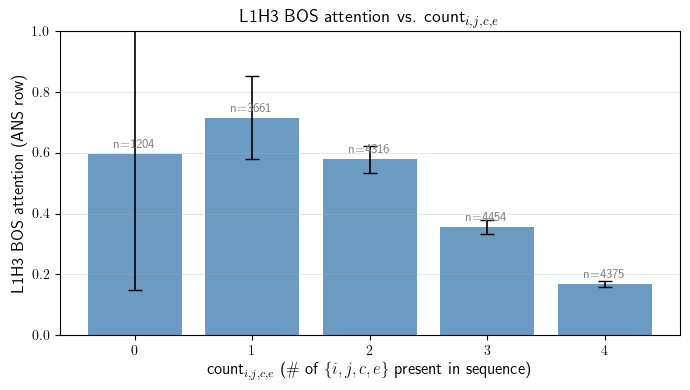

```python
"""
Plot L1H3 attention to BOS at the ANS row vs. count_{i,j,c,e}:
the number of tokens from {i,j,c,e} that appear at least once in the sequence.
"""

import json
import importlib
import importlib.util
from pathlib import Path

import numpy as np
import torch
import matplotlib.pyplot as plt
from torch.utils.data import DataLoader, TensorDataset
from huggingface_hub import hf_hub_download

# ── load model ────────────────────────────────────────────────────────────────
REPO_ID = "andyrdt/05_2026_puzzle_1"
model_py_path = hf_hub_download(REPO_ID, "model.py")
spec = importlib.util.spec_from_file_location("model", model_py_path)
model_module = importlib.util.module_from_spec(spec)
spec.loader.exec_module(model_module)
AttentionOnlyTransformer = model_module.AttentionOnlyTransformer

config = json.loads(Path(hf_hub_download(REPO_ID, "config.json")).read_text())
model = AttentionOnlyTransformer.from_config(config["model"])
model.load_state_dict(
    torch.load(hf_hub_download(REPO_ID, "model.pt"), map_location="cpu", weights_only=True)
)
model.eval()

vocab_cfg   = config["vocab"]
NUM_SYMBOLS = vocab_cfg["num_symbols"]
SEQ_LEN     = vocab_cfg["seq_len"]
BOS         = NUM_SYMBOLS
ANS         = NUM_SYMBOLS + 1
COUNT_BASE  = NUM_SYMBOLS + 2
ANS_POS     = 1 + SEQ_LEN

IJCE = {2, 4, 8, 9}   # c=2, e=4, i=8, j=9


# ── data generation ───────────────────────────────────────────────────────────
def generate_data(num_symbols, seq_len, samples_per_count=2000, seed=0):
    rng = np.random.default_rng(seed)
    all_seqs, all_targets = [], []
    for c in range(1, seq_len + 1):
        generated = set()
        attempts  = 0
        while len(generated) < samples_per_count and attempts < samples_per_count * 50:
            symbols = rng.choice(num_symbols, size=c, replace=False)
            extras  = rng.choice(symbols, size=seq_len - c, replace=True)
            seq     = np.concatenate([symbols, extras])
            rng.shuffle(seq)
            generated.add(tuple(int(x) for x in seq))
            attempts += 1
        for seq in generated:
            all_seqs.append([BOS] + list(seq) + [ANS])
            all_targets.append(COUNT_BASE + c - 1)
    inputs  = torch.tensor(all_seqs,    dtype=torch.long)
    targets = torch.tensor(all_targets, dtype=torch.long)
    return TensorDataset(inputs, targets)


print("Generating data...")
dataset = generate_data(NUM_SYMBOLS, SEQ_LEN, samples_per_count=2000, seed=0)
print(f"  {len(dataset)} examples")

# ── collect attention weights grouped by count_{i,j,c,e} ─────────────────────
by_count = {}

loader = DataLoader(dataset, batch_size=512, shuffle=False)
with torch.no_grad():
    for inputs, _ in loader:
        _, all_attns = model(inputs)
        bos_attn = all_attns[1][:, 3, ANS_POS, 0].cpu().numpy()  # (B,)
        seq_toks  = inputs[:, 1:SEQ_LEN + 1].cpu().numpy()        # (B, SEQ_LEN)
        for bi in range(len(inputs)):
            c = sum(1 for tok in IJCE if tok in seq_toks[bi])
            by_count.setdefault(c, []).append(bos_attn[bi])

xs    = sorted(by_count)
means = [np.mean(by_count[x]) for x in xs]
stds  = [np.std(by_count[x])  for x in xs]
ns    = [len(by_count[x])     for x in xs]

print("\ncount_{i,j,c,e} | n_samples | mean BOS attn | std")
for x, m, s, n in zip(xs, means, stds, ns):
    print(f"  {x}              | {n:8d} | {m:.4f}        | {s:.4f}")

# ── plot ──────────────────────────────────────────────────────────────────────
fig, ax = plt.subplots(figsize=(7, 4))
ax.bar(xs, means, yerr=stds, capsize=5, color="steelblue", alpha=0.8,
       error_kw=dict(elinewidth=1.2, ecolor="black"))
ax.set_xlabel(r"count$_{i,j,c,e}$  (\# of $\{i,j,c,e\}$ present in sequence)", fontsize=12)
ax.set_ylabel("L1H3 BOS attention (ANS row)", fontsize=12)
ax.set_title(r"L1H3 BOS attention vs. count$_{i,j,c,e}$", fontsize=13)
ax.set_xticks(xs)
ax.set_ylim(0, 1)
ax.grid(axis="y", alpha=0.3)
for x, m, n in zip(xs, means, ns):
    ax.text(x, m + 0.02, f"n={n}", ha="center", fontsize=9, color="gray")
fig.tight_layout()
plt.show()
```

Looking at the high standard deviation for count 0, in the figure below we will plot the average `BOS` tokens for samples where $\{i, j, c, e\}$ are not and compare it with respect to count of `b`(present or not).

```
Generating data...
  18010 examples

b present | n_samples | mean BOS attn | std
  absent  |      690 | 0.9801        | 0.0070
  present |      514 | 0.0814        | 0.0558
```

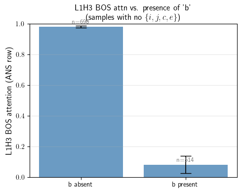

```python
"""
Plot L1H3 attention to BOS at the ANS row vs. whether 'b' is present,
using only samples that contain none of {i,j,c,e}.
"""

import json
import importlib
import importlib.util
from pathlib import Path

import numpy as np
import torch
import matplotlib.pyplot as plt
from torch.utils.data import DataLoader, TensorDataset
from huggingface_hub import hf_hub_download

# ── load model ────────────────────────────────────────────────────────────────
REPO_ID = "andyrdt/05_2026_puzzle_1"
model_py_path = hf_hub_download(REPO_ID, "model.py")
spec = importlib.util.spec_from_file_location("model", model_py_path)
model_module = importlib.util.module_from_spec(spec)
spec.loader.exec_module(model_module)
AttentionOnlyTransformer = model_module.AttentionOnlyTransformer

config = json.loads(Path(hf_hub_download(REPO_ID, "config.json")).read_text())
model = AttentionOnlyTransformer.from_config(config["model"])
model.load_state_dict(
    torch.load(hf_hub_download(REPO_ID, "model.pt"), map_location="cpu", weights_only=True)
)
model.eval()

vocab_cfg   = config["vocab"]
NUM_SYMBOLS = vocab_cfg["num_symbols"]
SEQ_LEN     = vocab_cfg["seq_len"]
BOS         = NUM_SYMBOLS
ANS         = NUM_SYMBOLS + 1
COUNT_BASE  = NUM_SYMBOLS + 2
ANS_POS     = 1 + SEQ_LEN

TOKEN_B  = 1          # 'b'
EXCLUDED = {2, 4, 8, 9}  # c=2, e=4, i=8, j=9


# ── data generation ───────────────────────────────────────────────────────────
def generate_data(num_symbols, seq_len, samples_per_count=2000, seed=0):
    rng = np.random.default_rng(seed)
    all_seqs, all_targets = [], []
    for c in range(1, seq_len + 1):
        generated = set()
        attempts  = 0
        while len(generated) < samples_per_count and attempts < samples_per_count * 50:
            symbols = rng.choice(num_symbols, size=c, replace=False)
            extras  = rng.choice(symbols, size=seq_len - c, replace=True)
            seq     = np.concatenate([symbols, extras])
            rng.shuffle(seq)
            generated.add(tuple(int(x) for x in seq))
            attempts += 1
        for seq in generated:
            all_seqs.append([BOS] + list(seq) + [ANS])
            all_targets.append(COUNT_BASE + c - 1)
    inputs  = torch.tensor(all_seqs,    dtype=torch.long)
    targets = torch.tensor(all_targets, dtype=torch.long)
    return TensorDataset(inputs, targets)


print("Generating data...")
dataset = generate_data(NUM_SYMBOLS, SEQ_LEN, samples_per_count=2000, seed=0)
print(f"  {len(dataset)} examples")

# ── collect attention weights, filtered to no {i,j,c,e} ──────────────────────
# grouped by whether 'b' is present (0 = absent, 1 = present)
by_present = {0: [], 1: []}

loader = DataLoader(dataset, batch_size=512, shuffle=False)
with torch.no_grad():
    for inputs, _ in loader:
        _, all_attns = model(inputs)
        bos_attn = all_attns[1][:, 3, ANS_POS, 0].cpu().numpy()  # (B,)
        seq_toks  = inputs[:, 1:SEQ_LEN + 1].cpu().numpy()        # (B, SEQ_LEN)
        for bi in range(len(inputs)):
            if any(t in EXCLUDED for t in seq_toks[bi]):
                continue
            present = int(TOKEN_B in seq_toks[bi])
            by_present[present].append(bos_attn[bi])

xs    = [0, 1]
means = [np.mean(by_present[x]) for x in xs]
stds  = [np.std(by_present[x])  for x in xs]
ns    = [len(by_present[x])     for x in xs]

print("\nb present | n_samples | mean BOS attn | std")
for x, m, s, n in zip(xs, means, stds, ns):
    label = "absent " if x == 0 else "present"
    print(f"  {label} | {n:8d} | {m:.4f}        | {s:.4f}")

# ── plot ──────────────────────────────────────────────────────────────────────
fig, ax = plt.subplots(figsize=(5, 4))
ax.bar(["b absent", "b present"], means, yerr=stds, capsize=8, color="steelblue",
       alpha=0.8, error_kw=dict(elinewidth=1.2, ecolor="black"))
ax.set_ylabel("L1H3 BOS attention (ANS row)", fontsize=12)
ax.set_title(r"L1H3 BOS attn vs. presence of 'b'" + "\n" + r"(samples with no $\{i,j,c,e\}$)", fontsize=12)
ax.set_ylim(0, 1)
ax.grid(axis="y", alpha=0.3)
for i, (m, n) in enumerate(zip(means, ns)):
    ax.text(i, m + 0.02, f"n={n}", ha="center", fontsize=9, color="gray")
fig.tight_layout()
plt.show()
```

Now we check our hypothesis for head 3 in layer 1:

The $\widetilde{OV}$ circuit output for layer 1 at `ANS` position comes from two cases:

- if count of $\{i,j,c,e\}$ = 1: $$ \widetilde{OV}(0.71* \widetilde{BOS} + \text{Uniform distribution on remaining tokens})$$
- if count of $\{i,j,c,e\}$ = 2: $$ \widetilde{OV}(0.57* \widetilde{BOS} + \text{Uniform distribution on remaining tokens})$$
- if count of $\{i,j,c,e\}$ = 3: $$ \widetilde{OV}(0.35* \widetilde{BOS} + \text{Uniform distribution on remaining tokens})$$
- if count of $\{i,j,c,e\}$ = 4: $$ \widetilde{OV}(0.16* \widetilde{BOS} + \text{Uniform distribution on remaining tokens})$$
- if count of $\{i,j,c,e\}$ = 0 and `b` present: $$ \widetilde{OV}(1*\tilde{B})$$
- if count of $\{i,j,c,e\}$ = 0 and `b` absent: $$ \widetilde{OV}(1* \widetilde{BOS})$$

```python
"""
L1H3 hypothesis check — nnsight version.

Uses `model` (NNsight wrapper) and `_raw` from cell 1,
and vocab constants (NUM_SYMBOLS, SEQ_LEN, BOS, ANS, COUNT_BASE, ANS_POS) from cell 3.

Hypothesis: the OV circuit input (attention-weighted values) at ANS position is:
  ijce_count=k (k=1..4): alpha_k * v[BOS] + (1-alpha_k)/11 * sum(v[1..11])
  ijce_count=0, b present: uniform over b-position value vectors
  ijce_count=0, b absent:  v[BOS] only

Alpha values: {1: 0.71, 2: 0.57, 3: 0.35, 4: 0.16}
IJCE = {c=2, e=4, i=8, j=9},  b = token 1
"""

import numpy as np
import torch
from torch.utils.data import DataLoader, TensorDataset

from nnsight import NNsight as _NNsight
_nn  = _NNsight(model)   # wrap cell-31 raw model
_raw = model              # keep reference for W_V access


IJCE      = {2, 4, 8, 9}
TOKEN_B   = 1
BOS_POS   = 0
N_REST    = ANS_POS          # positions 1..ANS_POS = 11

PATCH_LAYER = 1
PATCH_HEAD  = 3

CASE_ALPHA = {1: 0.71, 2: 0.57, 3: 0.35, 4: 0.16}


def _hyp_generate_data(num_symbols, seq_len, samples_per_count=500, seed=42):
    rng = np.random.default_rng(seed)
    all_seqs, all_targets = [], []
    for c in range(1, seq_len + 1):
        generated, attempts = set(), 0
        while len(generated) < samples_per_count and attempts < samples_per_count * 50:
            symbols = rng.choice(num_symbols, size=c, replace=False)
            extras  = rng.choice(symbols, size=seq_len - c, replace=True)
            seq     = np.concatenate([symbols, extras])
            rng.shuffle(seq)
            generated.add(tuple(int(x) for x in seq))
            attempts += 1
        for seq in generated:
            all_seqs.append([BOS] + list(seq) + [ANS])
            all_targets.append(COUNT_BASE + c - 1)
    inputs  = torch.tensor(all_seqs,    dtype=torch.long)
    targets = torch.tensor(all_targets, dtype=torch.long)
    return TensorDataset(inputs, targets)


def _compute_patched(inputs, v):
    """
    inputs : (B, S) token ids
    v      : (B, S, d_head) value vectors at layer 1 head 3
    returns: (B, d_head) patched head output at ANS_POS
    """
    B, _, d_head = v.shape
    patched = torch.zeros(B, d_head)
    for bi in range(B):
        seq_toks   = inputs[bi, 1:SEQ_LEN + 1].tolist()
        ijce_count = sum(1 for tok in IJCE if tok in seq_toks)
        if ijce_count > 0:
            alpha       = CASE_ALPHA[ijce_count]
            rest_weight = (1.0 - alpha) / N_REST
            patched[bi] = (
                alpha * v[bi, BOS_POS, :]
                + rest_weight * v[bi, 1:ANS_POS + 1, :].sum(dim=0)
            )
        else:
            b_pos = [p for p, tok in enumerate(seq_toks, start=1) if tok == TOKEN_B]
            if b_pos:
                patched[bi] = sum(v[bi, p, :] for p in b_pos) / len(b_pos)
            else:
                patched[bi] = v[bi, BOS_POS, :]
    return patched


def run_l1h3_hypothesis(dataset, batch_size=256):
    loader = DataLoader(dataset, batch_size=batch_size, shuffle=False)

    base_correct, hyp_correct, total = 0, 0, 0
    base_pc = {c: [0, 0] for c in range(1, SEQ_LEN + 1)}  # [correct, total]
    hyp_pc  = {c: [0, 0] for c in range(1, SEQ_LEN + 1)}
    case_correct, case_total = {}, {}

    for inputs, targets in loader:
        true_counts = (targets - COUNT_BASE + 1).numpy()

        # ── baseline ────────────────────────────────────────────────────────
        with _nn.trace(inputs):
            base_out = _nn.output.save()
        base_preds = base_out[0][:, ANS_POS].argmax(dim=-1)
        base_corr  = (base_preds == targets).numpy()
        base_correct += int(base_corr.sum())
        total        += len(targets)
        for c in range(1, SEQ_LEN + 1):
            m = true_counts == c
            base_pc[c][0] += int(base_corr[m].sum())
            base_pc[c][1] += int(m.sum())

        # ── extract value vectors via W_V output ─────────────────────────
        with _nn.trace(inputs):
            _v_saved = _nn.layers[PATCH_LAYER].heads[PATCH_HEAD].W_V.output.save()
        v = _v_saved

        # ── build patched head output ────────────────────────────────────
        patched = _compute_patched(inputs, v)

        # ── inject patch and collect logits ──────────────────────────────
        with _nn.trace(inputs):
            _nn.layers[PATCH_LAYER].heads[PATCH_HEAD].output[0][:, ANS_POS, :] = patched
            hyp_out = _nn.output.save()
        hyp_preds = hyp_out[0][:, ANS_POS].argmax(dim=-1)
        hyp_corr  = (hyp_preds == targets).numpy()
        hyp_correct += int(hyp_corr.sum())
        for c in range(1, SEQ_LEN + 1):
            m = true_counts == c
            hyp_pc[c][0] += int(hyp_corr[m].sum())
            hyp_pc[c][1] += int(m.sum())

        # ── per-case breakdown ───────────────────────────────────────────
        for bi in range(len(inputs)):
            seq_toks   = inputs[bi, 1:SEQ_LEN + 1].tolist()
            ijce_count = sum(1 for tok in IJCE if tok in seq_toks)
            key = (f"ijce={ijce_count}" if ijce_count > 0
                   else ("ijce=0,b=yes" if TOKEN_B in seq_toks else "ijce=0,b=no"))
            case_correct[key] = case_correct.get(key, 0) + int(hyp_corr[bi])
            case_total[key]   = case_total.get(key, 0) + 1

    return (
        base_correct / total,
        {c: base_pc[c][0] / base_pc[c][1] for c in range(1, SEQ_LEN+1) if base_pc[c][1] > 0},
        hyp_correct / total,
        {c: hyp_pc[c][0] / hyp_pc[c][1]  for c in range(1, SEQ_LEN+1) if hyp_pc[c][1]  > 0},
        case_correct, case_total,
    )


# ── Run ───────────────────────────────────────────────────────────────────────
print("Generating test data...")
_hyp_dataset = _hyp_generate_data(NUM_SYMBOLS, SEQ_LEN, samples_per_count=500, seed=42)
print(f"  {len(_hyp_dataset)} examples\n")

base_acc, base_pc_acc, hyp_acc, hyp_pc_acc, case_corr, case_tot = run_l1h3_hypothesis(_hyp_dataset)

print("=== Baseline ===")
print(f"  Overall: {base_acc:.4f}")
_tmp = {c: f"{v:.3f}" for c, v in base_pc_acc.items()}
print(f"  Per-count: {_tmp}\n")

print("=== Hypothesis patch — L1H3 ===")
print("  ijce=k:        alpha_k on BOS + uniform rest  {1:0.71, 2:0.57, 3:0.35, 4:0.16}")
print("  ijce=0, b=no:  all weight on BOS")
print("  ijce=0, b=yes: uniform over b-token positions")
print(f"  Overall: {hyp_acc:.4f}  (delta vs baseline: {hyp_acc - base_acc:+.4f})")
_tmp = {c: f"{v:.3f}" for c, v in hyp_pc_acc.items()}
print(f"  Per-count: {_tmp}\n")

print("=== Per-count delta ===")
for c in range(1, SEQ_LEN + 1):
    if c in base_pc_acc and c in hyp_pc_acc:
        d = hyp_pc_acc[c] - base_pc_acc[c]
        print(f"  count={c:2d}: baseline={base_pc_acc[c]:.3f}  patched={hyp_pc_acc[c]:.3f}  delta={d:+.4f}")

print("\n=== Case breakdown (patched model) ===")
for key in sorted(case_tot):
    n   = case_tot[key]
    acc = case_corr[key] / n
    print(f"  {key:20s}: n={n:5d}  acc={acc:.4f}")
```

```
Generating test data...
  4510 examples

=== Baseline ===
  Overall: 1.0000
  Per-count: {1: '1.000', 2: '1.000', 3: '1.000', 4: '1.000', 5: '1.000', 6: '1.000', 7: '1.000', 8: '1.000', 9: '1.000', 10: '1.000'}

=== Hypothesis patch — L1H3 ===
  ijce=k:        alpha_k on BOS + uniform rest  {1:0.71, 2:0.57, 3:0.35, 4:0.16}
  ijce=0, b=no:  all weight on BOS
  ijce=0, b=yes: uniform over b-token positions
  Overall: 0.9322  (delta vs baseline: -0.0678)
  Per-count: {1: '1.000', 2: '0.972', 3: '0.936', 4: '0.888', 5: '0.902', 6: '0.890', 7: '0.912', 8: '0.936', 9: '0.952', 10: '1.000'}

=== Per-count delta ===
  count= 1: baseline=1.000  patched=1.000  delta=+0.0000
  count= 2: baseline=1.000  patched=0.972  delta=-0.0280
  count= 3: baseline=1.000  patched=0.936  delta=-0.0640
  count= 4: baseline=1.000  patched=0.888  delta=-0.1120
  count= 5: baseline=1.000  patched=0.902  delta=-0.0980
  count= 6: baseline=1.000  patched=0.890  delta=-0.1100
  count= 7: baseline=1.000  patched=0.912  delta=-0.0880
  count= 8: baseline=1.000  patched=0.936  delta=-0.0640
  count= 9: baseline=1.000  patched=0.952  delta=-0.0480
  count=10: baseline=1.000  patched=1.000  delta=+0.0000

=== Case breakdown (patched model) ===
  ijce=0,b=no         : n=  168  acc=1.0000
  ijce=0,b=yes        : n=  143  acc=0.9790
  ijce=1              : n=  925  acc=0.8519
  ijce=2              : n= 1072  acc=0.9748
  ijce=3              : n= 1106  acc=0.9458
  ijce=4              : n= 1096  acc=0.9279
```

**Our analysis leaves several cases unexplored. For instance, we didn't explore cases when `b` or `f` are not present.We will continue the remaining analysis in the future.**